# Single cell data analysis

Shiwani Limbu

2024-02-27

## Including Plots

Pull single cell RNAseq data from Broad Institute Single cell database (https://singlecell.broadinstitute.org/single_cell/study/SCP1288/tumor-and-immune-reprogramming-during-immunotherapy-in-advanced-renal-cell-carcinoma?cluster=UMAP%20Cell%20Embeddings&spatialGroups=--&annotation=FinalCellType--group--cluster&subsample=all#/):

Load data

```r
library(Seurat)

data_dir <- 'D:/Research/Shiwani/SingleCell_MultiOmic/SCP1288/expression/60c76a18771a5b0ba10ea91b/'
seurat_object <- Read10X(data.dir = data_dir)
seurat_object = CreateSeuratObject(counts = seurat_object)
```

```r
seurat_object[["percent.mt"]] <- PercentageFeatureSet(seurat_object, pattern = "^MT-")
seurat_object[["percent.rb"]] <- PercentageFeatureSet(seurat_object, pattern = "^(RPL|RPS)")
seurat_object <- subset(seurat_object, subset = nFeature_RNA > 2)
seurat_object <- subset(seurat_object, subset = percent.mt < 20 & percent.rb < 50)
```

Normalization and variable feature identification

```r
invisible(capture.output({
  seurat_object <- NormalizeData(seurat_object, normalization.method = "LogNormalize", scale.factor = 10000)
  seurat_object <- FindVariableFeatures(seurat_object, selection.method = "vst", nfeatures = 2000)
}))
```

Find key Variable genes

```r
seurat_object <- FindVariableFeatures(seurat_object, selection.method = "vst", nfeatures = 2000)
```

Scaling gene expression data and run PCA

```r
invisible(capture.output({
seurat_object <- ScaleData(seurat_object)
seurat_object <- RunPCA(seurat_object, features = VariableFeatures(object = seurat_object))
}))
```

Check genes associated with each PC

```r
print(seurat_object[["pca"]], dims = 1:5, nfeatures = 5)
```

```
## PC_ 1
## Positive:  IGFBP5, RARRES2, CP, NDUFA4L2, FABP7
## Negative:  CCL4, LTB, CCL3, GZMB, CXCL13
## PC_ 2
## Positive:  IL32, CCL4, LTB, GZMB, ITM2C
## Negative:  C1QC, C1QA, C1QB, GRN, CTSB
## PC_ 3
## Positive:  COL4A2, COL4A1, TIMP3, VWF, HSPG2
## Negative:  PPDPFL, RPL7, FGG, RPL8, FRZB
## PC_ 4
## Positive:  ACSM2A, ACSM2B, SLC5A12, SLC17A3, PDK4
## Negative:  SPARCL1, MGP, VWF, SPARC, HSPG2
## PC_ 5
## Positive:  UBE2C, MKI67, BIRC5, TOP2A, AURKB
## Negative:  IGFBP5, IGHA1, IGKC, SPARCL1, EGFL7
```

Plot PCs

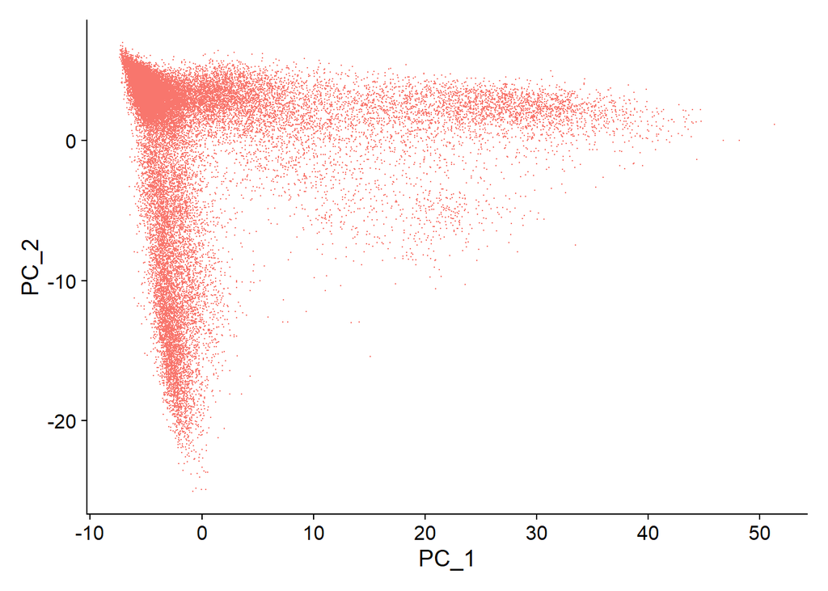

```r
DimPlot(seurat_object, reduction = "pca") + NoLegend()
```

Look for appropriate number of PCs

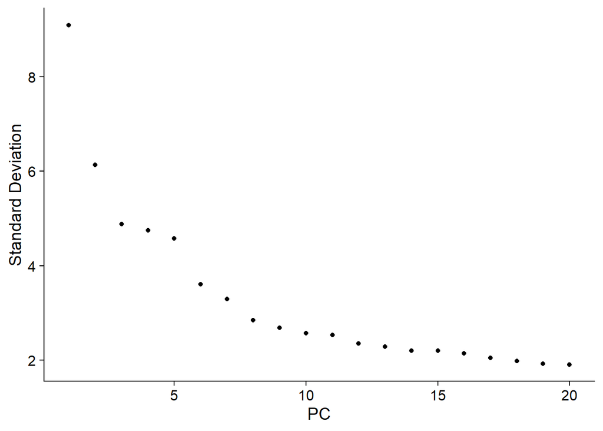

```r
ElbowPlot(seurat_object)
```

Elbow plot shows that there is not enough information loss beyong the first 12 PCs. Lets use these to find neighbor cells

```r
invisible(capture.output({
seurat_object <- FindNeighbors(seurat_object, dims = 1:12)
}))
```

Generate clusters

```r
invisible(capture.output({
seurat_object <- FindClusters(seurat_object, resolution = 1.18) # Adjust resolution as necessary
}))
```

Dimensionality Reduction and Visualization

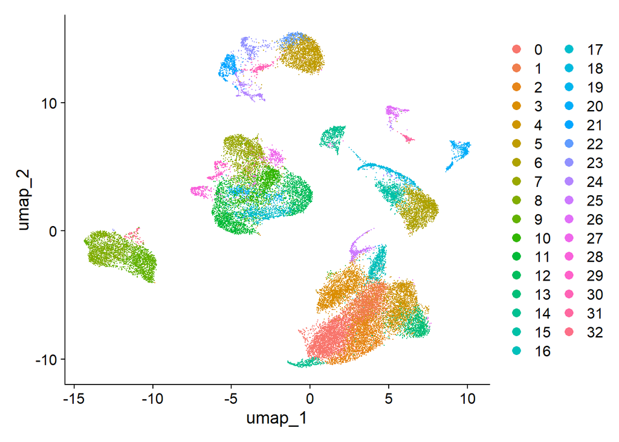

```r
invisible(capture.output({
seurat_object <- RunUMAP(seurat_object, dims = 1:12)
DimPlot(seurat_object, reduction = "umap")
}))
```

Finding cluster markers and identifying cell types

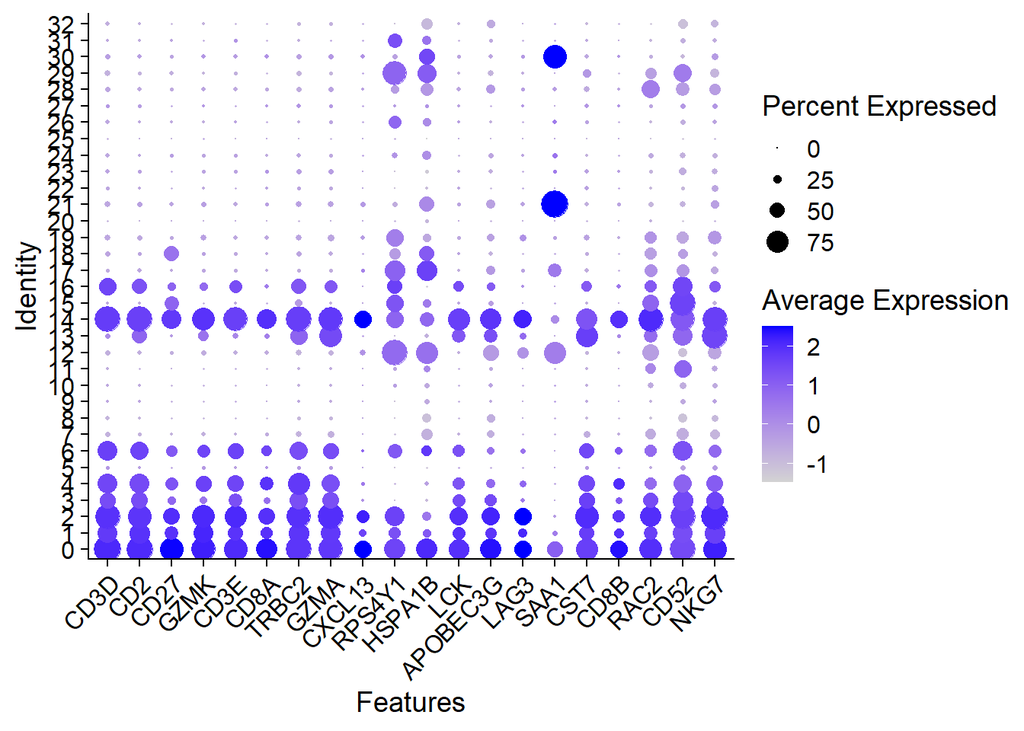

```r
invisible(capture.output({
markers <- FindAllMarkers(seurat_object, only.pos = TRUE, min.pct = 0.25, logfc.threshold = 0.25)
}))
DotPlot(seurat_object, features = rownames(markers[0:20,])) + RotatedAxis()
```

Ideally we would look at each cluster markers predicted in the previous step and assign a unique cell type label. Here, lets lets label each cell using its gene expression patterns.

```r
library(SingleR)
library(celldex)

# Prepare a SingleR reference dataset, or use one of the built-in references
# Human Primary Cell Atlas (HPCA) reference dataset for human
hpca.se <- HumanPrimaryCellAtlasData()

# Extracting expression data from Seurat object for SingleR
expression_data <- GetAssayData(seurat_object, assay = "RNA", slot = "data")

# Run SingleR
singleR_results <- SingleR(test = expression_data, ref = hpca.se, labels = hpca.se$label.main)
```

Lets plot cell types predicted by SingleR. Cell labels shown below look mostly consistent with the labels added at Broad Institute Single cell database entry page, although Astrocytes and Neurons are not expected cell types in renal cell carcinoma single cell data. These cell are likely mislabeled, and requires manual investigation by looking at its gene markers predicted in the clustering step, and effective communication with the bench scientists.

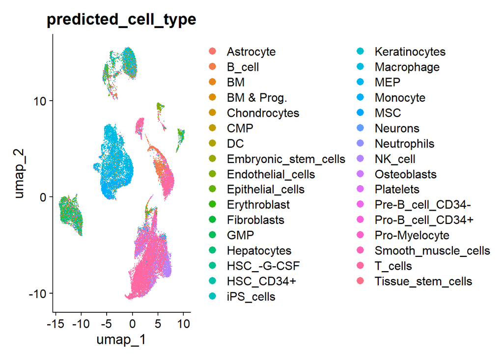

```r
# Add SingleR predictions to the Seurat object metadata
seurat_object$predicted_cell_type <- singleR_results$labels

# Plot UMAP with cells colored by their predicted cell types
DimPlot(seurat_object, reduction = "umap", group.by = "predicted_cell_type")
```